# PEC 5

UOC

**NOMBRE: Borja Villena Pardo**

# Introducción

En esta PEC utilizaremos el conjunto de datos ‘winequality-red.csv’ que contiene información técnica y gustativa de distintos tipos de vino tinto.

Se pueden consultar en https://archive.ics.uci.edu/ml/datasets/Wine+Quality

Las variables que contiene son las siguientes:

- acidez fija
- acidez volátil
- ácido cítrico
- azúcar residual
- cloruros
- dióxido de azufre libre
- dióxido de azufre total
- densidad
- pH
- sulfatos
- alcohol
- calidad

Os puede ser útil consultar el siguiente material:

- Módulos teóricos de Regresión lineal simple, múltiple y ANOVA.
- Actividades resueltas del Reto 5 (regresión lineal simple, múltiple y ANOVA).

Hay que entregar la práctica en fichero pdf o html (exportando el resultado final a pdf o html por ejemplo). Se recomienda generar el informe con Rmarkdown que genera automáticamente el pdf/html a entregar.

NOTA 1: no es necesario ni limpiar ni preprocesar los datos para este ejercicio

NOTA 2: comprobar que el dataset ha cargado correctamente (vigilar con la separación que se utiliza en el csv)

```r
## cargar datos
data_wine <- read.csv('data_pac5.csv', header = TRUE, sep = ';')
```

# Pregunta 1. (resolver con R). (3 puntos)

La empresa especializada en la creación de vinos de alta calidad está buscando comprender mejor las variables que influyen en la calidad del vino para optimizar sus estrategias de producción y marketing. Se realizará un análisis para identificar las características clave que contribuyen a la calidad del vino y determinar el enfoque para futuras campañas publicitarias.

1. Realiza un gráfico de dispersión entre la variable *citric.acid* y la variable *residual.sugar*. ¿Cuál es el coeficiente de correlación? Interpretad el resultado (1 punto).

**Solución:**

*Podemos observar que la correlación entre ambas variables es positiva y muy cercana a cero. Esto nos indica que la cantidad de azúcar residual no depende especialmente del ácido cítrico.*

```r
#Espacio para solución
Ácido_cítrico <- c(data_wine$citric.acid)
Azúcar_residual <- c(data_wine$residual.sugar)

# Creamos tabla con ambas variables
tabla_ci_az <- cbind(Ácido_cítrico, Azúcar_residual)

# Calculamos coeficiente de correlación lineal de Pearson
corr_ci_az <- cor(tabla_ci_az[,c('Ácido_cítrico', 'Azúcar_residual')],
                  use = 'complete.obs')

print(corr_ci_az)
```

```
##                 Ácido_cítrico Azúcar_residual
## Ácido_cítrico       1.0000000       0.1435772
## Azúcar_residual     0.1435772       1.0000000
```

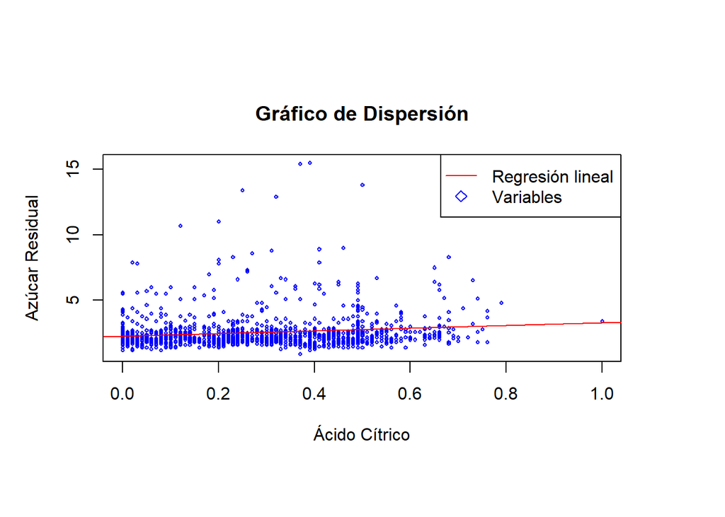

```r
# Realizamos gráfico del diagrama de dispersión y añadimos recta de regresión
# para una mejor visualización

par(pin=c(5, 2))

plot(Ácido_cítrico, Azúcar_residual, pch = 5, col = 'blue', cex = 0.3, main = 'Gráfico de Dispersión', xlab = "Ácido Cítrico", ylab = "Azúcar Residual")

abline(lm(Azúcar_residual~Ácido_cítrico), col = 'red')

legend('topright', legend = c('Regresión lineal', 'Variables'),
       col = c('red','blue'), lty = c(1,0), pch = c(-1, 5))
```

2. Encontrad los siguientes dos parámetros del modelo de regresión lineal a estudiar: el intercepto ($B_0$) y la pendiente ($B_1$). Nota: Usa citric.acid como variable dependiente (1 punto).

**Solución:**

```r
#Espacio para solución

# Lo calculamos de manera de manual
B_1_pend <- cov(Azúcar_residual, Ácido_cítrico) / var(Azúcar_residual)

B_0_inter <- mean(Ácido_cítrico) - B_1_pend * mean(Azúcar_residual)

print(c(B_0_inter,  B_1_pend))
```

```
## [1] 0.22061287 0.01983718
```

```r
# Ahora lo calculamos usando la instrucción lm de R para comprobar que los datos coinciden
mod_regresion <- lm(Ácido_cítrico ~ Azúcar_residual)
print(mod_regresion)
```

```
##
## Call:
## lm(formula = Ácido_cítrico ~ Azúcar_residual)
##
## Coefficients:
##     (Intercept)  Azúcar_residual
##         0.22061          0.01984
```

*El valor del intercepto* $B_0$ *es* 0.2206129  
*El valor de la pendiente* $B_1$ *es* 0.0198372

3. ¿Qué porcentaje de la variación en la calidad del vino (ácido cítrico) no puede ser explicado por los Azúcar_residuales residuales? (1 punto)

**Solución:**

```r
#Espacio para solución

# Adquirimos el coeficiente de determinación
r_2 <- summary(mod_regresion)$r.squared

# Calculamos el porcentaje de variación no explicada
porc_no <- (1 - r_2) * 100
```

*La proporción de la variación en la variable ‘Calidad_vino’ explicada por la variable ‘Azúcar_residual’, es decir, el coeficiente de determinación* $R^2$ *es* 0.0206144

*El porcentaje de la variación en la calidad del vino que no puede ser explicada por la variable de Azúcar_residuales es del* 97.94 *%*

# Pregunta 2. (resolver con R). (3 puntos)

Para la creación de la próxima versión mejorada de vinos tintos, se han seleccionado distintos vinos y se han sometido a diversas catas.

Se procederá inicialmente a analizar los datos obtenidos de la evaluación de la influencia de la cantidad de sulfatos en la calidad del vino. Se buscará determinar si existen diferencias significativas entre las cantidades de la variable *sulphates* para distintos grupos definidos por la calidad (variable Quality_group **no disponible en el dataset**).

1. ¿Cuántos grupos y cuántas observaciones hay en el dataset? (1 punto)

2. Si se utiliza el nivel de significación $\alpha = 0.05$, ¿qué valor crítico se debe utilizar para realizar el análisis de la varianza? (1 punto)

**Solución:**

```r
#Espacio para solución

# Definimos valor de alpha
alpha <- 0.05

# Definimos los grados de libertad de numerador y denominador
grado_numerador <- 3
grado_denominador <- 1595

# Calculamos el valor crítico
vc <- qf(alpha, grado_numerador, grado_denominador, lower.tail = F)
print(vc)
```

```
## [1] 2.610481
```

*El valor crítico es* 2.6104813

3. ¿Cuál es la conclusión del análisis de la varianza (con un nivel de significación del 5%) en función del valor crítico? (1 punto)

**Solución:**

# Pregunta 3 (resolver con R). (4 puntos)

Exploraremos un modelo predictivo sobre la calidad del vino utilizando múltiples variables:

1. Escribe la ecuación que se obtiene del modelo de regresión múltiple para predecir la calidad del vino utilizando las variables de pH, contenido de azúcar residual y sulfatos. (1 punto)

**Solución:**

```r
#Espacio para solución
calidad <- c(data_wine$quality)
ph <- c(data_wine$pH)
sulfato <- c(data_wine$sulphates)

mod_reg_multiple <- lm(calidad ~ ph + Azúcar_residual + sulfato,
                       data = data_wine)

print(summary(mod_reg_multiple))
```

```
##
## Call:
## lm(formula = calidad ~ ph + Azúcar_residual + sulfato, data = data_wine)
##
## Residuals:
##     Min      1Q  Median      3Q     Max
## -3.2617 -0.5460  0.1185  0.4541  2.3886
##
## Coefficients:
##                  Estimate Std. Error t value Pr(>|t|)
## (Intercept)      4.967242   0.456120  10.890   <2e-16 ***
## ph              -0.039750   0.129763  -0.306    0.759
## Azúcar_residual  0.006701   0.013932   0.481    0.631
## sulfato          1.190285   0.117755  10.108   <2e-16 ***
## ---
## Signif. codes:  0 '***' 0.001 '**' 0.01 '*' 0.05 '.' 0.1 ' ' 1
##
## Residual standard error: 0.7823 on 1595 degrees of freedom
## Multiple R-squared:  0.06341,    Adjusted R-squared:  0.06165
## F-statistic: 35.99 on 3 and 1595 DF,  p-value: < 2.2e-16
```

```r
ecuacion = paste("Calidad = ", round((coef(mod_reg_multiple))[1], 3), " + (",
                 round((coef(mod_reg_multiple))[2], 3), ") * pH + ",
                 round((coef(mod_reg_multiple))[3], 3), " * AzucarResidual + ",
                 round((coef(mod_reg_multiple))[4], 3), " * Sulfatos", sep = "")

print(ecuacion)
```

```
## [1] "Calidad = 4.967 + (-0.04) * pH + 0.007 * AzucarResidual + 1.19 * Sulfatos"
```

*La ecuación que se obtiene es:*

Calidad = 4.967 + (-0.04) * pH + 0.007 * AzucarResidual + 1.19 * Sulfatos

2. ¿El modelo en su conjunto es significativo con un nivel del 5%? Además, ¿cuál es el coeficiente de determinación obtenido para este modelo? (1 punto)

**Solución:**

*El modelo en su conjunto es significativo ya que el p-valor* <2.2e-16> *es menor que* 0.05 (5 %)

*El coeficiente de determinación es:* 0.0634079

3. Dado un vino con un pH de 3.5, un contenido de azúcar residual de 2.5 y sulfatos de 0.6, ¿cuál sería su calidad según el modelo establecido? (1 punto)

**Solución:**

```r
#Espacio para solución

b0 <- ((coef(mod_reg_multiple))[1])
b1 <- ((coef(mod_reg_multiple))[2])
b2 <- ((coef(mod_reg_multiple))[3])
b3 <- ((coef(mod_reg_multiple))[4])

calculo_calidad <- b0 + b1 * 3.5 + b2 * 2.5 + b3 * 0.6

print(calculo_calidad)
```

```
## (Intercept)
##     5.55904
```

*Su calidad sería:* 5.5590405

4. Si tuvieras que eliminar alguna variable del modelo del apartado a), considerando un nivel de significación del 5%, ¿cuál eliminarías y por qué? (1 punto).

**Solución:**

*Eliminaría la variable ‘ph’, ya que su p-valor es* 0.759 *. Al ser un valor mayor que alpha = 0.05 (5%), nos impidiría rechazar la hipótesis nula, por lo que no sería una variable significativa para predecir la calidad del vino.*

*Teniendo en cuenta el mismo razonamiento, también podríamos optar por eliminar la variable ‘Azúcar_residual’, aunque su p-valor* 0.631*, que también excede de 0.05, es algo menor que la variable ‘ph’.*